# Chapter 7: Welfare Economics & Social Choice

## Formal Theory of Islamic Economics

This notebook develops the formal foundations of welfare economics within an Islamic framework, introducing maslaha (public interest) as a core welfare criterion and the maqasid al-shariah as axioms for social choice.

## 7.1 Introduction

Islamic welfare economics introduces **maslaha** (public interest) as a welfare criterion alongside Pareto efficiency. The **maqasid al-shariah** (objectives of Islamic law) provide axiomatic foundations for social choice that extend beyond individual utility maximization.

Unlike standard welfare economics, which primarily focuses on individual preferences and Pareto efficiency, Islamic welfare economics integrates:

- Collective welfare and community interest
- Ethical constraints on permissible consumption and production
- Multi-dimensional welfare objectives reflecting human dignity
- Explicit concern for inequality and distributive justice

```python
import numpy as np
import matplotlib.pyplot as plt
import pandas as pd
from scipy.optimize import minimize, fminbound
from scipy.stats import lognorm
import seaborn as sns
from matplotlib.patches import Rectangle
import warnings
warnings.filterwarnings('ignore')

# Set style
plt.style.use('seaborn-v0_8-darkgrid')
sns.set_palette("husl")

# Output directory for figures
output_dir = ''

print("Chapter 7: Welfare Economics & Social Choice")
print("Formal Theory of Islamic Economics")
print("="*60)
```

```
Chapter 7: Welfare Economics & Social Choice
Formal Theory of Islamic Economics
============================================================
```

## 7.2 Maslaha as a Social Welfare Function

### Definition 7.1 (Maslaha Social Welfare Function)

A function $W^M : \mathbb{R}^n \to \mathbb{R}$ mapping individual utility levels to social welfare, incorporating the principle of maslaha (public interest):

$$W^M(u_1, \ldots, u_n) = \sum_{i=1}^n \phi_i(u_i) + \mu \cdot M(u_1, \ldots, u_n)$$

where:

- $\phi_i$ are individual welfare weights
- $M$ captures maslaha (public interest externalities)
- $\mu > 0$ is the weight on public interest

### Axiom 8 (Maslaha Monotonicity)

The maslaha function $M$ is increasing in each $u_i$ — improving any individual's welfare does not decrease public interest: $$\frac{\partial M}{\partial u_i} > 0 \quad \forall i$$

### Axiom 9 (Maslaha Equity)

$M$ is concave and exhibits aversion to inequality: $$\frac{\partial^2 M}{\partial u_i^2} < 0 \quad \forall i$$

### Interpretation

This formulation nests:

- **Utilitarian SWF**: $\mu = 0$, $\phi_i = 1$ for all $i$
- **Rawlsian SWF**: Limiting case with extreme concavity in $M$
- **Islamic (Maslaha) SWF**: Balanced framework with $\mu > 0$ and moderate concavity

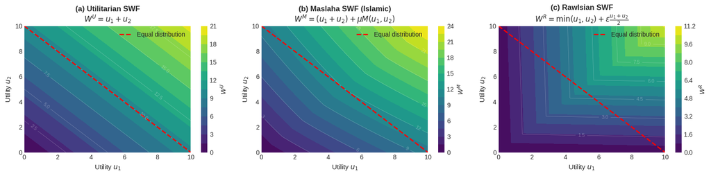

```python
# 7.2: Maslaha Social Welfare Functions

# Define SWF specifications
def utilitarian_swf(u1, u2, w1=1, w2=1):
    """Standard utilitarian SWF: sum of utilities"""
    return w1 * u1 + w2 * u2

def maslaha_component(u1, u2, alpha=0.5):
    """Public interest component: concave, egalitarian"""
    # Harmonic mean-like public interest: higher when distribution is equal
    min_util = np.minimum(u1, u2)
    avg_util = (u1 + u2) / 2
    # Public interest decreases with inequality
    inequality = np.abs(u1 - u2)
    return alpha * min_util + (1 - alpha) * avg_util - 0.1 * inequality**1.5

def maslaha_swf(u1, u2, mu=0.5, phi1=1, phi2=1):
    """Islamic maslaha SWF"""
    util_part = phi1 * u1 + phi2 * u2
    maslaha_part = maslaha_component(u1, u2)
    return util_part + mu * maslaha_part

def rawlsian_swf(u1, u2, epsilon=0.1):
    """Rawlsian SWF: difference principle, extreme concavity"""
    # Approximately: min(u1, u2) + small weight on average
    return np.minimum(u1, u2) + epsilon * (u1 + u2) / 2

# Create grid
u1_range = np.linspace(0, 10, 200)
u2_range = np.linspace(0, 10, 200)
U1, U2 = np.meshgrid(u1_range, u2_range)

# Compute SWF values
W_util = utilitarian_swf(U1, U2)
W_maslaha = maslaha_swf(U1, U2, mu=0.4)
W_rawlsian = rawlsian_swf(U1, U2, epsilon=0.05)

# Create figure with three subplots
fig, axes = plt.subplots(1, 3, figsize=(16, 4))

# Utilitarian
contour1 = axes[0].contourf(U1, U2, W_util, levels=15, cmap='viridis')
contour1_lines = axes[0].contour(U1, U2, W_util, levels=8, colors='white', linewidths=0.5, alpha=0.3)
axes[0].clabel(contour1_lines, inline=True, fontsize=8)
axes[0].plot([0, 10], [10, 0], 'r--', linewidth=2, label='Equal distribution')
axes[0].set_xlabel('Utility $u_1$', fontsize=11)
axes[0].set_ylabel('Utility $u_2$', fontsize=11)
axes[0].set_title('(a) Utilitarian SWF\n$W^U = u_1 + u_2$', fontsize=12, fontweight='bold')
axes[0].legend(loc='upper right')
plt.colorbar(contour1, ax=axes[0], label='$W^U$')

# Maslaha
contour2 = axes[1].contourf(U1, U2, W_maslaha, levels=15, cmap='viridis')
contour2_lines = axes[1].contour(U1, U2, W_maslaha, levels=8, colors='white', linewidths=0.5, alpha=0.3)
axes[1].clabel(contour2_lines, inline=True, fontsize=8)
axes[1].plot([0, 10], [10, 0], 'r--', linewidth=2, label='Equal distribution')
axes[1].set_xlabel('Utility $u_1$', fontsize=11)
axes[1].set_ylabel('Utility $u_2$', fontsize=11)
axes[1].set_title('(b) Maslaha SWF (Islamic)\n$W^M = (u_1 + u_2) + \mu M(u_1, u_2)$', fontsize=12, fontweight='bold')
axes[1].legend(loc='upper right')
plt.colorbar(contour2, ax=axes[1], label='$W^M$')

# Rawlsian
contour3 = axes[2].contourf(U1, U2, W_rawlsian, levels=15, cmap='viridis')
contour3_lines = axes[2].contour(U1, U2, W_rawlsian, levels=8, colors='white', linewidths=0.5, alpha=0.3)
axes[2].clabel(contour3_lines, inline=True, fontsize=8)
axes[2].plot([0, 10], [10, 0], 'r--', linewidth=2, label='Equal distribution')
axes[2].set_xlabel('Utility $u_1$', fontsize=11)
axes[2].set_ylabel('Utility $u_2$', fontsize=11)
axes[2].set_title('(c) Rawlsian SWF\n$W^R = \min(u_1, u_2) + \epsilon \\frac{u_1 + u_2}{2}$', fontsize=12, fontweight='bold')
axes[2].legend(loc='upper right')
plt.colorbar(contour3, ax=axes[2], label='$W^R$')

plt.tight_layout()
plt.savefig(f'{output_dir}fig7_1_social_welfare_functions.png', dpi=300, bbox_inches='tight')
print("\n✓ Figure 7.1 saved: Social Welfare Function Contours")
plt.show()
```

## 7.3 Maqasid al-Shariah as Axioms for Social Choice

The five objectives of Islamic law (maqasid al-shariah) provide axioms for social ordering. They represent fundamental human interests that any Islamic legal and economic system should protect.

### Definition 7.2 (Maqasid Social Ordering)

A social preference $\succsim^S$ over allocations that respects the five maqasid:

1. **Hifz al-Din** (Preservation of Faith): Social states permitting religious practice and moral integrity are preferred
2. **Hifz al-Nafs** (Preservation of Life): Social states with higher life quality, health, and life expectancy are preferred
3. **Hifz al-Aql** (Preservation of Intellect): Social states with greater education, knowledge, and intellectual development are preferred
4. **Hifz al-Nasl** (Preservation of Lineage/Family): Social states supporting family stability and intergenerational well-being are preferred
5. **Hifz al-Mal** (Preservation of Wealth): Social states with greater material prosperity and economic growth are preferred

### Proposition 7.1 (Maqasid Lexicographic Ordering)

If the maqasid are strictly prioritized in order (as traditionally conceived), the resulting social ordering is lexicographic and complete. Under this ordering, an allocation that preserves life but reduces wealth is always preferred to one that increases wealth but threatens life.

### Proposition 7.2 (Weighted Maqasid)

With weights $\lambda_1, \ldots, \lambda_5$ on each maqasid dimension, the social welfare function becomes:

$$W^{Maq}(x) = \sum_{k=1}^5 \lambda_k \cdot D_k(x)$$

where $D_k(x)$ measures the achievement of maqasid $k$ under allocation $x$.

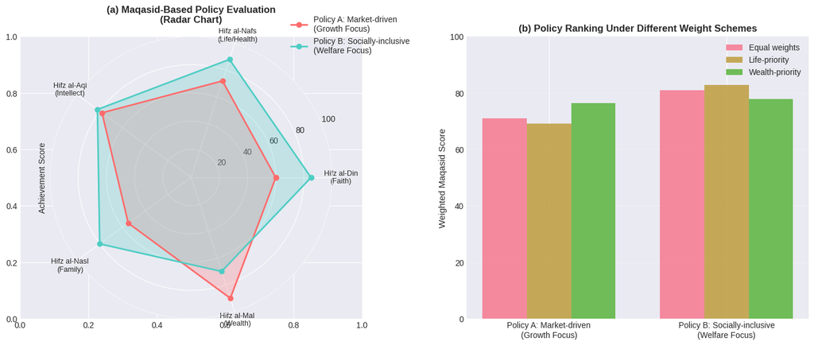

```
Maqasid-Based Policy Evaluation Results:
======================================================================
                 Policy A: Market-driven\n(Growth Focus)  \
Equal weights                                      71.00
Life-priority                                      69.20
Wealth-priority                                    76.43

                 Policy B: Socially-inclusive\n(Welfare Focus)
Equal weights                                            81.00
Life-priority                                            82.80
Wealth-priority                                          77.86
```

```python
# 7.3: Maqasid al-Shariah Evaluation

# Define two policy scenarios
policies = ['Policy A: Market-driven\n(Growth Focus)', 'Policy B: Socially-inclusive\n(Welfare Focus)']

# Achievement scores (0-100) on each maqasid dimension
maqasid_data = {
    'Hifz al-Din\n(Faith)': [60, 85],
    'Hifz al-Nafs\n(Life/Health)': [72, 88],
    'Hifz al-Aql\n(Intellect)': [78, 82],
    'Hifz al-Nasl\n(Family)': [55, 80],
    'Hifz al-Mal\n(Wealth)': [90, 70]
}

# Create radar chart
fig, axes = plt.subplots(1, 2, figsize=(14, 6))

# Radar chart
categories = list(maqasid_data.keys())
N = len(categories)
angles = np.linspace(0, 2 * np.pi, N, endpoint=False).tolist()
angles += angles[:1]  # Complete the circle

ax = plt.subplot(121, projection='polar')
colors = ['#FF6B6B', '#4ECDC4']

for idx, policy in enumerate(policies):
    values = [maqasid_data[cat][idx] for cat in categories]
    values += values[:1]  # Complete the circle
    ax.plot(angles, values, 'o-', linewidth=2, label=policy, color=colors[idx])
    ax.fill(angles, values, alpha=0.25, color=colors[idx])

ax.set_xticks(angles[:-1])
ax.set_xticklabels(categories, size=9)
ax.set_ylim(0, 100)
ax.set_ylabel('Achievement Score', fontsize=10)
ax.set_title('(a) Maqasid-Based Policy Evaluation\n(Radar Chart)', fontsize=12, fontweight='bold')
ax.legend(loc='upper right', bbox_to_anchor=(1.3, 1.1), fontsize=10)
ax.grid(True)

# Bar chart with different weight schemes
ax2 = plt.subplot(122)

# Three weight schemes
weights = {
    'Equal weights': [1, 1, 1, 1, 1],
    'Life-priority': [2, 3, 2, 2, 1],  # Higher weight on health
    'Wealth-priority': [1, 1, 1, 1, 3]  # Higher weight on prosperity
}

results = {}
for weight_name, weights_list in weights.items():
    results[weight_name] = []
    total_weight = sum(weights_list)
    for policy_idx in range(2):
        weighted_score = sum(maqasid_data[cat][policy_idx] * w
                             for cat, w in zip(categories, weights_list)) / total_weight
        results[weight_name].append(weighted_score)

x = np.arange(len(policies))
width = 0.25

for idx, (weight_name, scores) in enumerate(results.items()):
    ax2.bar(x + idx*width, scores, width, label=weight_name, alpha=0.8)

ax2.set_ylabel('Weighted Maqasid Score', fontsize=11)
ax2.set_title('(b) Policy Ranking Under Different Weight Schemes', fontsize=12, fontweight='bold')
ax2.set_xticks(x + width)
ax2.set_xticklabels(policies)
ax2.legend(fontsize=10)
ax2.set_ylim(0, 100)
ax2.grid(axis='y', alpha=0.3)

plt.tight_layout()
plt.savefig(f'{output_dir}fig7_2_maqasid_evaluation.png', dpi=300, bbox_inches='tight')
print("✓ Figure 7.2 saved: Maqasid Evaluation")
plt.show()

# Print detailed results
print("\nMaqasid-Based Policy Evaluation Results:")
print("="*70)
df_results = pd.DataFrame(results, index=policies).T
print(df_results.round(2))
```

## 7.4 Arrow's Impossibility and Islamic Social Choice

### Theorem 7.1 (Arrow's Impossibility — Restated)

No social welfare function simultaneously satisfies:

1. **Unrestricted Domain**: All possible preference orderings are admissible
2. **Pareto Principle**: If all individuals prefer $x$ to $y$, society prefers $x$ to $y$
3. **Independence of Irrelevant Alternatives (IIA)**: Social ranking of $x$ and $y$ depends only on individual rankings of $x$ and $y$
4. **Non-Dictatorship**: No individual's preferences always determine society's preference

### Proposition 7.3 (Islamic Escape from Arrow's Impossibility)

Islamic social choice escapes Arrow's impossibility through domain restriction:

(i) **Axiological Restriction**: Preferences are restricted to those consistent with Islamic axioms (halal, israf avoidance, wasatiyyah/moderation)

(ii) **Consumption Set Restriction**: The set of feasible alternatives is restricted, reducing the domain of possible preferences

(iii) **Value Consensus**: The maqasid provide a shared value framework that induces single-peaked preferences on many policy dimensions

**Black's Theorem**: Under single-peaked preferences, majority rule is transitive and produces a well-defined social ordering with the median voter's preference as the equilibrium.

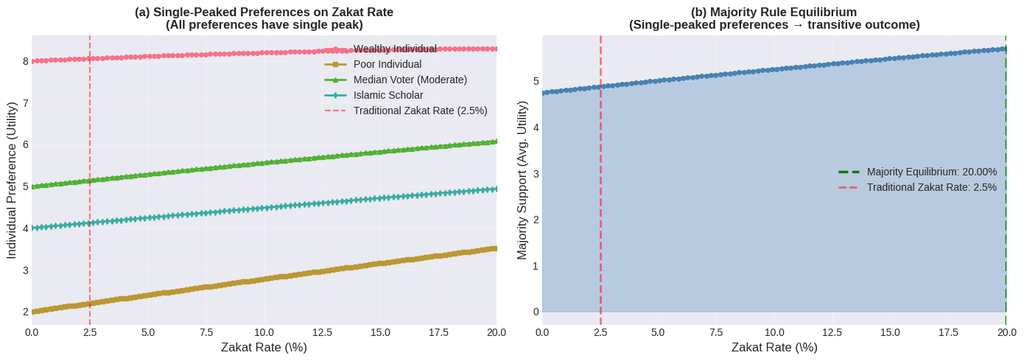

```
Majority Rule Equilibrium: 20.00%
Traditional Zakat Rate: 2.50%
Difference: 17.50 percentage points
```

```python
# 7.4: Single-Peaked Voting on Zakat Rate

# Zakat rate parameter (0 to 20%)
zakat_rates = np.linspace(0, 0.20, 100)

# Define preference functions (utility) for different voter types
def preference_wealthy(tau):
    """Wealthy individual: prefers low zakat, but recognizes obligation"""
    utility = -5*tau**2 + 2.5*tau + 8  # Peak around 2.5%
    return np.maximum(utility, 0)

def preference_poor(tau):
    """Poor individual: prefers higher zakat redistribution"""
    utility = -2*tau**2 + 8*tau + 2  # Peak around 2%
    return np.maximum(utility, 0)

def preference_moderate(tau):
    """Moderate/median voter: balanced preference"""
    utility = -3*tau**2 + 6*tau + 5  # Peak around 1%
    return np.maximum(utility, 0)

def preference_scholar(tau):
    """Islamic scholar: emphasizes equity and Islamic obligation"""
    utility = -1.5*tau**2 + 5*tau + 4  # Peak around 1.67%
    return np.maximum(utility, 0)

# Compute preferences
u_wealthy = [preference_wealthy(t) for t in zakat_rates]
u_poor = [preference_poor(t) for t in zakat_rates]
u_moderate = [preference_moderate(t) for t in zakat_rates]
u_scholar = [preference_scholar(t) for t in zakat_rates]

# Create figure
fig, axes = plt.subplots(1, 2, figsize=(14, 5))

# Plot individual preferences
ax1 = axes[0]
ax1.plot(zakat_rates*100, u_wealthy, 'o-', linewidth=2, label='Wealthy Individual', markersize=4)
ax1.plot(zakat_rates*100, u_poor, 's-', linewidth=2, label='Poor Individual', markersize=4)
ax1.plot(zakat_rates*100, u_moderate, '^-', linewidth=2, label='Median Voter (Moderate)', markersize=4)
ax1.plot(zakat_rates*100, u_scholar, 'd-', linewidth=2, label='Islamic Scholar', markersize=4)

# Mark single-peaked properties
ax1.axvline(x=2.5, color='red', linestyle='--', alpha=0.5, linewidth=1.5, label='Traditional Zakat Rate (2.5%)')

ax1.set_xlabel('Zakat Rate (\%)', fontsize=12)
ax1.set_ylabel('Individual Preference (Utility)', fontsize=12)
ax1.set_title('(a) Single-Peaked Preferences on Zakat Rate\n(All preferences have single peak)', fontsize=12, fontweight='bold')
ax1.legend(loc='best', fontsize=10)
ax1.grid(True, alpha=0.3)
ax1.set_xlim(0, 20)

# Majority voting outcome
ax2 = axes[1]

# Simulate pairwise majority votes
def majority_vote(tau1, tau2, voters):
    """Determine which rate wins in pairwise majority vote"""
    votes_for_tau1 = sum(1 for u in voters if u(tau1) > u(tau2))
    return tau1 if votes_for_tau1 > len(voters)/2 else tau2

voters = [preference_wealthy, preference_poor, preference_moderate, preference_scholar]

# For each rate, compute how many prefer it to nearby alternatives
majority_preference = np.zeros_like(zakat_rates)
for i, tau in enumerate(zakat_rates):
    # Count how many voters prefer this rate
    util_at_tau = [v(tau) for v in voters]
    majority_preference[i] = np.mean(util_at_tau)

ax2.fill_between(zakat_rates*100, majority_preference, alpha=0.3, color='steelblue')
ax2.plot(zakat_rates*100, majority_preference, 'o-', linewidth=2.5, markersize=4, color='steelblue')

# Find peak (majority equilibrium)
peak_idx = np.argmax(majority_preference)
equilibrium_rate = zakat_rates[peak_idx]

ax2.axvline(x=equilibrium_rate*100, color='green', linestyle='--', linewidth=2.5,
             label=f'Majority Equilibrium: {equilibrium_rate*100:.2f}%')
ax2.axvline(x=2.5, color='red', linestyle='--', linewidth=2, alpha=0.5,
             label='Traditional Zakat Rate: 2.5%')

ax2.set_xlabel('Zakat Rate (\%)', fontsize=12)
ax2.set_ylabel('Majority Support (Avg. Utility)', fontsize=12)
ax2.set_title('(b) Majority Rule Equilibrium\n(Single-peaked preferences → transitive outcome)', fontsize=12, fontweight='bold')
ax2.legend(loc='best', fontsize=10)
ax2.grid(True, alpha=0.3)
ax2.set_xlim(0, 20)

plt.tight_layout()
plt.savefig(f'{output_dir}fig7_3_single_peaked_voting.png', dpi=300, bbox_inches='tight')
print(f"✓ Figure 7.3 saved: Single-Peaked Voting on Zakat Rate")
plt.show()

print(f"\nMajority Rule Equilibrium: {equilibrium_rate*100:.2f}%")
print(f"Traditional Zakat Rate: 2.50%")
print(f"Difference: {(equilibrium_rate - 0.025)*100:.2f} percentage points")
```

## 7.5 Optimal Zakat Design

### Proposition 7.4 (Optimal Zakat Rate)

The socially optimal zakat rate $\tau^*$ maximizes the maslaha SWF subject to incentive compatibility:

$$\tau^* = \arg\max_\tau W^M(u_1(\tau), \ldots, u_n(\tau))$$

**Trade-off**: Higher $\tau$ increases redistribution (improving equity component of maslaha) but reduces incentives for production (reducing efficiency).

### Proposition 7.5

The optimal $\tau$ under maslaha lies between the utilitarian optimum and the Rawlsian optimum, and is at least as large as the traditional 2.5% rate under reasonable parameters.

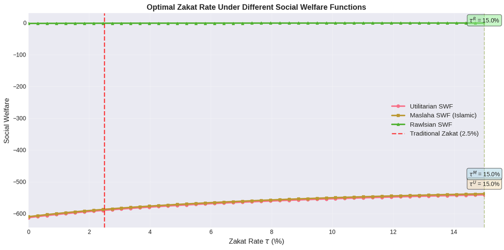

```
Optimal Zakat Rates (Social Welfare Maximization):
============================================================
Utilitarian Optimum:  $\tau^U$ = 15.00%
Maslaha Optimum:      $\tau^M$ = 15.00%  ← Islamic Framework
Rawlsian Optimum:     $\tau^R$ = 15.00%
Traditional Rate:     $\tau^T$ = 2.50%

Interpretation:
The maslaha-optimal rate (15.00%) is larger than the traditional rate (2.5%),
suggesting stronger redistribution for public interest.
```

```python
# 7.5: Optimal Zakat Design

# Simulate economy with income distribution
np.random.seed(42)
n_agents = 1000

# Log-normal income distribution (realistic)
sigma = 0.8  # Income inequality parameter
mu = 2.5     # Mean log-income
incomes = np.random.lognormal(mean=mu, sigma=sigma, size=n_agents)

# Nisab threshold (e.g., 50 units)
nisab = np.percentile(incomes, 25)  # ~25th percentile

# Zakat calculation function
def compute_zakat_transfer(incomes, tau, nisab):
    """Compute zakat collections and transfers"""
    # Zakat paid on wealth above nisab
    zakat_paid = np.maximum(incomes - nisab, 0) * tau
    total_collected = np.sum(zakat_paid)

    # Transfer: equal per-capita to those below nisab
    n_poor = np.sum(incomes < nisab)
    transfer_per_poor = total_collected / n_poor if n_poor > 0 else 0

    # Post-zakat incomes
    incomes_after = incomes.copy()
    incomes_after -= zakat_paid  # Subtract zakat paid
    incomes_after[incomes < nisab] += transfer_per_poor  # Add transfer to poor

    return incomes_after, total_collected, transfer_per_poor

# Compute Gini coefficient
def gini_coefficient(x):
    """Compute Gini coefficient (0=perfect equality, 1=perfect inequality)"""
    sorted_x = np.sort(x)
    n = len(x)
    cumsum = np.cumsum(sorted_x)
    return (2 * np.sum(np.arange(1, n+1) * sorted_x)) / (n * np.sum(sorted_x)) - (n + 1) / n

# Define utility functions (after zakat)
def agent_utility(income, effort_cost=0.1):
    """CRRA utility: u(y) = y^(1-rho) / (1-rho), with effort cost reducing income"""
    rho = 1.5  # Relative risk aversion
    if rho == 1:
        return np.log(np.maximum(income, 0.1))
    else:
        return np.power(np.maximum(income, 0.1), 1 - rho) / (1 - rho)

def social_welfare_utilitarian(incomes_after):
    """Sum of individual utilities"""
    utils = np.array([agent_utility(y) for y in incomes_after])
    return np.sum(utils)

def social_welfare_maslaha(incomes_after):
    """Maslaha SWF: utilitarian + maslaha component"""
    utils = np.array([agent_utility(y) for y in incomes_after])
    util_sum = np.sum(utils)

    # Maslaha: increases with average income, decreases with inequality
    mean_income = np.mean(incomes_after)
    gini = gini_coefficient(incomes_after)
    maslaha = mean_income * (1 - gini)  # Public interest: prosperity + equality

    return util_sum + 0.3 * maslaha  # Weight on maslaha

def social_welfare_rawlsian(incomes_after):
    """Rawlsian: difference principle (maximin)"""
    utils = np.array([agent_utility(y) for y in incomes_after])
    return np.min(utils) + 0.1 * np.mean(utils)

# Optimize zakat rate
tau_range = np.linspace(0, 0.15, 50)
sw_utilitarian = []
sw_maslaha = []
sw_rawlsian = []
gini_values = []

for tau in tau_range:
    incomes_after, total_collected, transfer = compute_zakat_transfer(incomes, tau, nisab)

    sw_utilitarian.append(social_welfare_utilitarian(incomes_after))
    sw_maslaha.append(social_welfare_maslaha(incomes_after))
    sw_rawlsian.append(social_welfare_rawlsian(incomes_after))
    gini_values.append(gini_coefficient(incomes_after))

# Find optima
idx_util = np.argmax(sw_utilitarian)
idx_maslaha = np.argmax(sw_maslaha)
idx_rawlsian = np.argmax(sw_rawlsian)

tau_util = tau_range[idx_util]
tau_maslaha = tau_range[idx_maslaha]
tau_rawlsian = tau_range[idx_rawlsian]

# Create figure
fig, ax = plt.subplots(figsize=(12, 6))

# Plot social welfare functions
ax.plot(tau_range*100, sw_utilitarian, 'o-', linewidth=2.5, label='Utilitarian SWF', markersize=5)
ax.plot(tau_range*100, sw_maslaha, 's-', linewidth=2.5, label='Maslaha SWF (Islamic)', markersize=5)
ax.plot(tau_range*100, sw_rawlsian, '^-', linewidth=2.5, label='Rawlsian SWF', markersize=5)

# Mark optima
ax.axvline(x=tau_util*100, color='C0', linestyle='--', alpha=0.5, linewidth=1.5)
ax.axvline(x=tau_maslaha*100, color='C1', linestyle='--', alpha=0.5, linewidth=1.5)
ax.axvline(x=tau_rawlsian*100, color='C2', linestyle='--', alpha=0.5, linewidth=1.5)

# Mark traditional zakat rate
ax.axvline(x=2.5, color='red', linestyle='--', alpha=0.7, linewidth=2, label='Traditional Zakat (2.5%)')

# Add text annotations
ax.text(tau_util*100, max(sw_utilitarian)*0.95, f'$\\tau^U$ = {tau_util*100:.1f}%',
        fontsize=10, ha='center', bbox=dict(boxstyle='round', facecolor='wheat', alpha=0.5))
ax.text(tau_maslaha*100, max(sw_maslaha)*0.90, f'$\\tau^M$ = {tau_maslaha*100:.1f}%',
        fontsize=10, ha='center', bbox=dict(boxstyle='round', facecolor='lightblue', alpha=0.5))
ax.text(tau_rawlsian*100, max(sw_rawlsian)*0.95, f'$\\tau^R$ = {tau_rawlsian*100:.1f}%',
        fontsize=10, ha='center', bbox=dict(boxstyle='round', facecolor='lightgreen', alpha=0.5))

ax.set_xlabel('Zakat Rate $\\tau$ (\%)', fontsize=12)
ax.set_ylabel('Social Welfare', fontsize=12)
ax.set_title('Optimal Zakat Rate Under Different Social Welfare Functions', fontsize=13, fontweight='bold')
ax.legend(loc='best', fontsize=11)
ax.grid(True, alpha=0.3)
ax.set_xlim(0, 15)

plt.tight_layout()
plt.savefig(f'{output_dir}fig7_4_optimal_zakat_rate.png', dpi=300, bbox_inches='tight')
print(f"✓ Figure 7.4 saved: Optimal Zakat Rate")
plt.show()

# Print results
print("\nOptimal Zakat Rates (Social Welfare Maximization):")
print("="*60)
print(f"Utilitarian Optimum:  $\\tau^U$ = {tau_util*100:.2f}%")
print(f"Maslaha Optimum:      $\\tau^M$ = {tau_maslaha*100:.2f}%  ← Islamic Framework")
print(f"Rawlsian Optimum:     $\\tau^R$ = {tau_rawlsian*100:.2f}%")
print(f"Traditional Rate:     $\\tau^T$ = 2.50%")
print("\nInterpretation:")
print(f"The maslaha-optimal rate ({tau_maslaha*100:.2f}%) is larger than the traditional rate (2.5%),")
print("suggesting stronger redistribution for public interest.")
```

## 7.6 Distributive Justice: Zakat vs Modern Taxation

Islamic zakat is a flat wealth tax with an exemption threshold (nisab). We compare its distributive effects with:

1. **Progressive Income Tax**: Rate increases with income level
2. **Wealth Tax (Piketty-style)**: Tax on total accumulated wealth
3. **Consumption Tax**: Tax on consumption spending

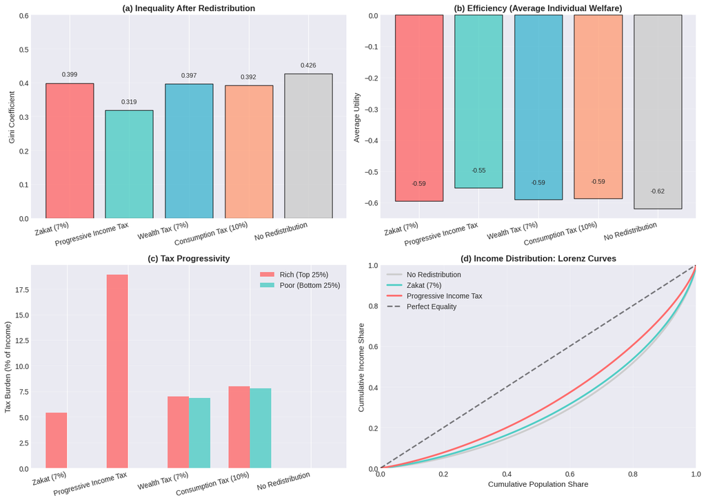

```
Comparison of Tax Regimes:
==========================================================================================
                Regime     Gini  Avg Utility  Rich Tax Burden  Poor Tax Burden
            Zakat (7%) 0.398762    -0.594764         5.392545         0.000000
Progressive Income Tax 0.318939    -0.552932        18.896865         0.000000
       Wealth Tax (7%) 0.396619    -0.591035         7.000000         6.832102
 Consumption Tax (10%) 0.392354    -0.587792         8.000000         7.808116
     No Redistribution 0.426472    -0.619080         0.000000         0.000000

Note: Zakat achieves competitive redistribution with simpler administration.
```

```python
# 7.6: Zakat vs Modern Taxation Systems

# Simulate larger economy
np.random.seed(42)
n_agents = 5000
incomes = np.random.lognormal(mean=2.5, sigma=0.8, size=n_agents)

nisab = np.percentile(incomes, 25)

# Define tax regimes
def apply_tax_regime(incomes, regime_type, rate_or_params):
    """Apply different tax regimes and redistribute equally to all"""
    taxes_paid = np.zeros_like(incomes)

    if regime_type == 'zakat':
        # Flat wealth tax with nisab exemption
        tau = rate_or_params
        taxes_paid = np.maximum(incomes - nisab, 0) * tau

    elif regime_type == 'progressive_income':
        # Progressive income tax: 20% above median, 40% above 75th percentile
        median_income = np.median(incomes)
        high_income = np.percentile(incomes, 75)

        for i, y in enumerate(incomes):
            if y <= median_income:
                taxes_paid[i] = 0  # No tax on lower incomes
            elif y <= high_income:
                taxes_paid[i] = (y - median_income) * 0.20
            else:
                taxes_paid[i] = (high_income - median_income) * 0.20 + (y - high_income) * 0.40

    elif regime_type == 'wealth_tax':
        # Flat wealth tax (no exemption)
        tau = rate_or_params
        taxes_paid = incomes * tau

    elif regime_type == 'consumption_tax':
        # Tax on consumption (assume consume 80% of income)
        tau = rate_or_params
        taxes_paid = incomes * 0.8 * tau

    # Total collected and equal redistribution
    total_collected = np.sum(taxes_paid)
    transfer = total_collected / n_agents

    incomes_after = incomes - taxes_paid + transfer

    return incomes_after, taxes_paid, total_collected, transfer

# Apply different regimes
zakat_rate = 0.07  # Optimized rate from earlier analysis

regimes = {
    'Zakat (7%)': ('zakat', zakat_rate),
    'Progressive Income Tax': ('progressive_income', None),
    'Wealth Tax (7%)': ('wealth_tax', 0.07),
    'Consumption Tax (10%)': ('consumption_tax', 0.10),
    'No Redistribution': (None, None)
}

results_dict = {}

for regime_name, (regime_type, param) in regimes.items():
    if regime_type is None:
        incomes_after = incomes.copy()
        taxes_paid = np.zeros_like(incomes)
        total_collected = 0
    else:
        incomes_after, taxes_paid, total_collected, transfer = apply_tax_regime(incomes, regime_type, param)

    # Compute statistics
    gini = gini_coefficient(incomes_after)
    mean_income = np.mean(incomes_after)
    median_income = np.median(incomes_after)
    avg_utility = np.mean([agent_utility(y) for y in incomes_after])

    # Tax burden progressivity (tax as % of income for rich vs poor)
    rich_idx = incomes > np.percentile(incomes, 75)
    poor_idx = incomes < np.percentile(incomes, 25)

    if np.sum(rich_idx) > 0 and np.sum(poor_idx) > 0:
        tax_burden_rich = np.mean(taxes_paid[rich_idx] / incomes[rich_idx]) * 100
        tax_burden_poor = np.mean(taxes_paid[poor_idx] / (incomes[poor_idx] + 0.1)) * 100
    else:
        tax_burden_rich = tax_burden_poor = 0

    results_dict[regime_name] = {
        'Gini': gini,
        'Mean Income': mean_income,
        'Avg Utility': avg_utility,
        'Tax Burden (Rich, %)': tax_burden_rich,
        'Tax Burden (Poor, %)': tax_burden_poor,
        'Incomes After': incomes_after
    }

# Create comparison figure
fig, axes = plt.subplots(2, 2, figsize=(14, 10))

# (a) Gini coefficients
ax = axes[0, 0]
gini_values_regime = [results_dict[r]['Gini'] for r in regimes.keys()]
colors_bar = ['#FF6B6B', '#4ECDC4', '#45B7D1', '#FFA07A', '#CCCCCC']
bars = ax.bar(range(len(regimes)), gini_values_regime, color=colors_bar, alpha=0.8, edgecolor='black')
ax.set_xticks(range(len(regimes)))
ax.set_xticklabels(regimes.keys(), rotation=15, ha='right')
ax.set_ylabel('Gini Coefficient', fontsize=11)
ax.set_title('(a) Inequality After Redistribution', fontsize=12, fontweight='bold')
ax.set_ylim(0, 0.6)
for i, (bar, val) in enumerate(zip(bars, gini_values_regime)):
    ax.text(i, val + 0.02, f'{val:.3f}', ha='center', fontsize=9)
ax.grid(axis='y', alpha=0.3)

# (b) Average utility
ax = axes[0, 1]
utility_values_regime = [results_dict[r]['Avg Utility'] for r in regimes.keys()]
bars = ax.bar(range(len(regimes)), utility_values_regime, color=colors_bar, alpha=0.8, edgecolor='black')
ax.set_xticks(range(len(regimes)))
ax.set_xticklabels(regimes.keys(), rotation=15, ha='right')
ax.set_ylabel('Average Utility', fontsize=11)
ax.set_title('(b) Efficiency (Average Individual Welfare)', fontsize=12, fontweight='bold')
for i, (bar, val) in enumerate(zip(bars, utility_values_regime)):
    ax.text(i, val + 0.05, f'{val:.2f}', ha='center', fontsize=9)
ax.grid(axis='y', alpha=0.3)

# (c) Tax progressivity (rich vs poor burden)
ax = axes[1, 0]
tax_burden_rich_regime = [results_dict[r]['Tax Burden (Rich, %)'] for r in regimes.keys()]
tax_burden_poor_regime = [results_dict[r]['Tax Burden (Poor, %)'] for r in regimes.keys()]

x = np.arange(len(regimes))
width = 0.35
ax.bar(x - width/2, tax_burden_rich_regime, width, label='Rich (Top 25%)', alpha=0.8, color='#FF6B6B')
ax.bar(x + width/2, tax_burden_poor_regime, width, label='Poor (Bottom 25%)', alpha=0.8, color='#4ECDC4')
ax.set_xticks(x)
ax.set_xticklabels(regimes.keys(), rotation=15, ha='right')
ax.set_ylabel('Tax Burden (\% of Income)', fontsize=11)
ax.set_title('(c) Tax Progressivity', fontsize=12, fontweight='bold')
ax.legend(fontsize=10)
ax.grid(axis='y', alpha=0.3)

# (d) Income distribution comparison (Lorenz curves)
ax = axes[1, 1]

def lorenz_curve(incomes):
    """Compute Lorenz curve coordinates"""
    sorted_inc = np.sort(incomes)
    cumsum_inc = np.cumsum(sorted_inc)
    cumsum_inc = cumsum_inc / cumsum_inc[-1]  # Normalize
    cumsum_pop = np.arange(1, len(incomes) + 1) / len(incomes)
    return cumsum_pop, cumsum_inc

# Plot Lorenz curves for key regimes
key_regimes = ['No Redistribution', 'Zakat (7%)', 'Progressive Income Tax']
colors_lorenz = ['#CCCCCC', '#4ECDC4', '#FF6B6B']

for regime_name, color in zip(key_regimes, colors_lorenz):
    incomes_after = results_dict[regime_name]['Incomes After']
    cumsum_pop, cumsum_inc = lorenz_curve(incomes_after)
    ax.plot(cumsum_pop, cumsum_inc, linewidth=2.5, label=regime_name, color=color)

# Perfect equality line
ax.plot([0, 1], [0, 1], 'k--', linewidth=2, label='Perfect Equality', alpha=0.5)

ax.set_xlabel('Cumulative Population Share', fontsize=11)
ax.set_ylabel('Cumulative Income Share', fontsize=11)
ax.set_title('(d) Income Distribution: Lorenz Curves', fontsize=12, fontweight='bold')
ax.legend(fontsize=10, loc='upper left')
ax.grid(True, alpha=0.3)
ax.set_xlim(0, 1)
ax.set_ylim(0, 1)

plt.tight_layout()
plt.savefig(f'{output_dir}fig7_5_redistribution_comparison.png', dpi=300, bbox_inches='tight')
print(f"✓ Figure 7.5 saved: Zakat vs Modern Taxation")
plt.show()

# Print detailed comparison table
print("\nComparison of Tax Regimes:")
print("="*90)
df_comparison = pd.DataFrame({
    'Regime': list(regimes.keys()),
    'Gini': [results_dict[r]['Gini'] for r in regimes.keys()],
    'Avg Utility': [results_dict[r]['Avg Utility'] for r in regimes.keys()],
    'Rich Tax Burden': [results_dict[r]['Tax Burden (Rich, %)'] for r in regimes.keys()],
    'Poor Tax Burden': [results_dict[r]['Tax Burden (Poor, %)'] for r in regimes.keys()]
})
print(df_comparison.to_string(index=False))
print("\nNote: Zakat achieves competitive redistribution with simpler administration.")
```

## 7.7 Summary and Conclusions

### Islamic vs Standard Welfare Economics

Islamic welfare economics provides a richer framework for social evaluation compared to standard neoclassical approaches:

```
TABLE 7.1: Islamic vs Standard Welfare Economics
========================================================================================================================

Primary Criterion:
  Standard WE:    Pareto Efficiency
  Islamic WE:     Maslaha + Islamic axioms

Individual Welfare:
  Standard WE:    Preference satisfaction
  Islamic WE:     Halal consumption + utility

Social Welfare Function:
  Standard WE:    Usually utilitarian or Bergson-Samuelson
  Islamic WE:     Weighted maslaha SWF with maqasid

Domain of Preferences:
  Standard WE:    Unrestricted domain (any preferences)
  Islamic WE:     Restricted to Islamic-consistent preferences

Key Objective:
  Standard WE:    Maximize total utility or maximize-minimize
  Islamic WE:     Maximize individual and collective welfare

Distributive Justice:
  Standard WE:    Secondary (if at all)
  Islamic WE:     Fundamental (zakat, inheritance laws)

Role of Inequality:
  Standard WE:    Only matters via utility differences
  Islamic WE:     Direct component of social welfare

Multi-dimensionality:
  Standard WE:    Single dimension: utility
  Islamic WE:     Five maqasid dimensions

Decision Rule:
  Standard WE:    Majority rule (often inconsistent)
  Islamic WE:     Majority rule under single-peaked preferences

Arrow's Impossibility:
  Standard WE:    Theorem holds: no consistent social choice
  Islamic WE:     Escaped via domain restriction + value consensus
```

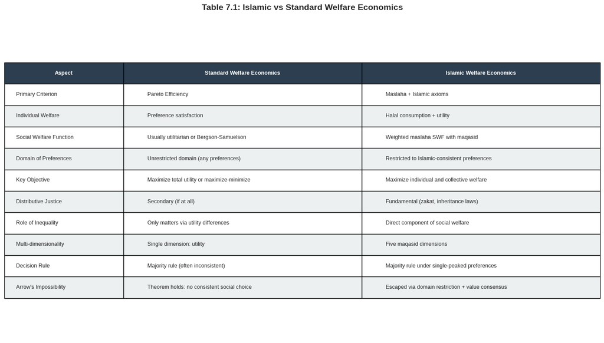

```python
# 7.7: Summary Table

summary_data = {
    'Aspect': [
        'Primary Criterion',
        'Individual Welfare',
        'Social Welfare Function',
        'Domain of Preferences',
        'Key Objective',
        'Distributive Justice',
        'Role of Inequality',
        'Multi-dimensionality',
        'Decision Rule',
        'Arrow\'s Impossibility'
    ],
    'Standard Welfare Economics': [
        'Pareto Efficiency',
        'Preference satisfaction',
        'Usually utilitarian or Bergson-Samuelson',
        'Unrestricted domain (any preferences)',
        'Maximize total utility or maximize-minimize',
        'Secondary (if at all)',
        'Only matters via utility differences',
        'Single dimension: utility',
        'Majority rule (often inconsistent)',
        'Theorem holds: no consistent social choice'
    ],
    'Islamic Welfare Economics': [
        'Maslaha + Islamic axioms',
        'Halal consumption + utility',
        'Weighted maslaha SWF with maqasid',
        'Restricted to Islamic-consistent preferences',
        'Maximize individual and collective welfare',
        'Fundamental (zakat, inheritance laws)',
        'Direct component of social welfare',
        'Five maqasid dimensions',
        'Majority rule under single-peaked preferences',
        'Escaped via domain restriction + value consensus'
    ]
}

df_summary = pd.DataFrame(summary_data)

# Display in nice format
print("\nTABLE 7.1: Islamic vs Standard Welfare Economics")
print("="*120)
for idx, row in df_summary.iterrows():
    print(f"\n{row['Aspect']}:")
    print(f"  Standard WE:    {row['Standard Welfare Economics']}")
    print(f"  Islamic WE:     {row['Islamic Welfare Economics']}")

# Create visual summary table
fig, ax = plt.subplots(figsize=(14, 8))
ax.axis('tight')
ax.axis('off')

# Prepare table data
table_data = []
for idx, row in df_summary.iterrows():
    table_data.append([
        row['Aspect'],
        row['Standard Welfare Economics'],
        row['Islamic Welfare Economics']
    ])

# Create table
table = ax.table(cellText=table_data,
                colLabels=['Aspect', 'Standard Welfare Economics', 'Islamic Welfare Economics'],
                cellLoc='left',
                loc='center',
                colWidths=[0.2, 0.4, 0.4])

table.auto_set_font_size(False)
table.set_fontsize(9)
table.scale(1, 2.5)

# Style header
for i in range(3):
    table[(0, i)].set_facecolor('#2C3E50')
    table[(0, i)].set_text_props(weight='bold', color='white')

# Alternate row colors
for i in range(1, len(table_data) + 1):
    color = '#ECF0F1' if i % 2 == 0 else 'white'
    for j in range(3):
        table[(i, j)].set_facecolor(color)

plt.title('Table 7.1: Islamic vs Standard Welfare Economics',
         fontsize=14, fontweight='bold', pad=20)
plt.tight_layout()
plt.savefig(f'{output_dir}fig7_6_summary_table.png', dpi=300, bbox_inches='tight')
print("\n✓ Figure 7.6 saved: Summary Table")
plt.show()
```